# Querying using SQL and R

Bryan Whiting

2021-10-11

# Create a Database from CSV

Create a database (loaded from CSV):

```r
library(DBI)
con <- dbConnect(RSQLite::SQLite(), db=here::here('data-raw/data.db'))
df <- readr::read_csv(here::here("data-raw/data.csv"))
dbWriteTable(con, 'test', df, overwrite=T)
dbDisconnect(con)
```

# Read from Database

```r
con <- dbConnect(RSQLite::SQLite(), db=here::here('data-raw/data.db'))
res <- dbSendQuery(con, "SELECT * FROM test")
dbFetch(res)
```

| id | s | p | v | t |
| --- | --- | --- | --- | --- |
| 1 | s1 | sub | s1.2 | 1 |
| 2 | s1 | sub | s1.1 | 2 |
| 3 | s1.1 | h | TRUE | 3 |
| 4 | s1.2 | h | TRUE | 4 |
| 5 | s1.1 | w | FALSE | 5 |
| 6 | s1 | a | TRUE | 6 |
| 7 | s2 | h | TRUE | 1 |
| 9 | s2 | a | TRUE | 4 |
| 10 | s2 | w | FALSE | 8 |
| 11 | s3 | a | TRUE | 1 |

[output cut: 6 more lines]

# Sample Data (SQL)

```sql
select *
from test
```

Displaying records 1 - 10

| id | s | p | v | t |
| --- | --- | --- | --- | --- |
| 1 | s1 | sub | s1.2 | 1 |
| 2 | s1 | sub | s1.1 | 2 |
| 3 | s1.1 | h | TRUE | 3 |
| 4 | s1.2 | h | TRUE | 4 |
| 5 | s1.1 | w | FALSE | 5 |
| 6 | s1 | a | TRUE | 6 |
| 7 | s2 | h | TRUE | 1 |
| 9 | s2 | a | TRUE | 4 |
| 10 | s2 | w | FALSE | 8 |
| 11 | s3 | a | TRUE | 1 |

# SQL approach

```sql
with t1 as (
  select *,
  case when p = "sub" or INSTR(s, ".") = 0 then s
      else substr(s, 1, INSTR(s, ".") - 1)
      end as s_clean,
    RANK() OVER(partition by
      case when p = "sub" or INSTR(s, ".") = 0 then s
      else substr(s, 1, INSTR(s, ".") - 1)
      end
      order by t) as r
  from test
  where (s LIKE "s1%" OR s LIKE "s2%")
  AND s not in (
    select distinct s
    from test
    where p = "sub"
  )
)
select s, s_clean,
  max(case when p = 'h' then v end) as h,
  max(case when p = 'w' then v end) as w,
  max(case when p = 'a' then v end) as a
from t1
where s in (select distinct(s) from t1 where r = 1)
group by 1, 2
```

2 records

| s | s_clean | h | w | a |
| --- | --- | --- | --- | --- |
| s1.1 | s1 | TRUE | FALSE | NA |
| s2 | s2 | TRUE | FALSE | TRUE |

# R

```r
library(readr)
library(dplyr)
library(tidyr)
library(stringr)
res <- dbSendQuery(con, "SELECT * FROM test")
df <- dbFetch(res)

keep = c('s1', "s2")

df %>%
  filter(str_detect(s, paste(keep, collapse="|"))) %>%
  mutate(
    x = str_extract(s, "\\w[0-9]*"),
    s_clean = ifelse(is.na(x), s, x)
   ) %>%
  filter(!(s %in% (df %>% filter(p == "sub") %>% distinct(s)))) %>%
  group_by(s_clean) %>%
  mutate(keep_s = row_number() == 1) %>%
  group_by(s) %>%
  filter(max(keep_s) == TRUE) %>%
  select(s, s_clean, p, v) %>%
  pivot_wider(names_from=p, values_from=v) %>%
  DT::datatable()
#   Warning: Values are not uniquely identified; output will contain list-cols.
#   * Use `values_fn = list` to suppress this warning.
#   * Use `values_fn = length` to identify where the duplicates arise
#   * Use `values_fn = {summary_fun}` to summarise duplicates
```

|  | s | s_clean | sub | a | h | w |
| --- | --- | --- | --- | --- | --- | --- |
| 1 | s1 | s1 | ['s1.2', 's1.1'] | TRUE |  |  |
| 2 | s2 | s2 |  | TRUE | TRUE | FALSE |

# Building an App and API

To make a full-stack solution to this problem, it’d be best for the end user to either have access to a web app (user-friend) or an API (for backend systems). I built both and left details steps on how to replicate my work (see [README](https://github.com/bryanwhiting/sqlite_test). A demo and summary is below.

## Overview

- App is hosted at apps.bryanwhiting.com
- API is hosted at apps.bryanwhiting.com:8080/ with endpoints apps.bryanwhiting.com:8080/inspect for data inspection and apps.bryanwhiting.com:8080/plot for plots.

## App

I built a web app available at apps.bryanwhiting.com.

The goal of this app is to make it easy for users to search their serial numbers and get back clean data (the same processing done above in this example).

### Data Inspection

On the landing page, the dash shows all the raw data.

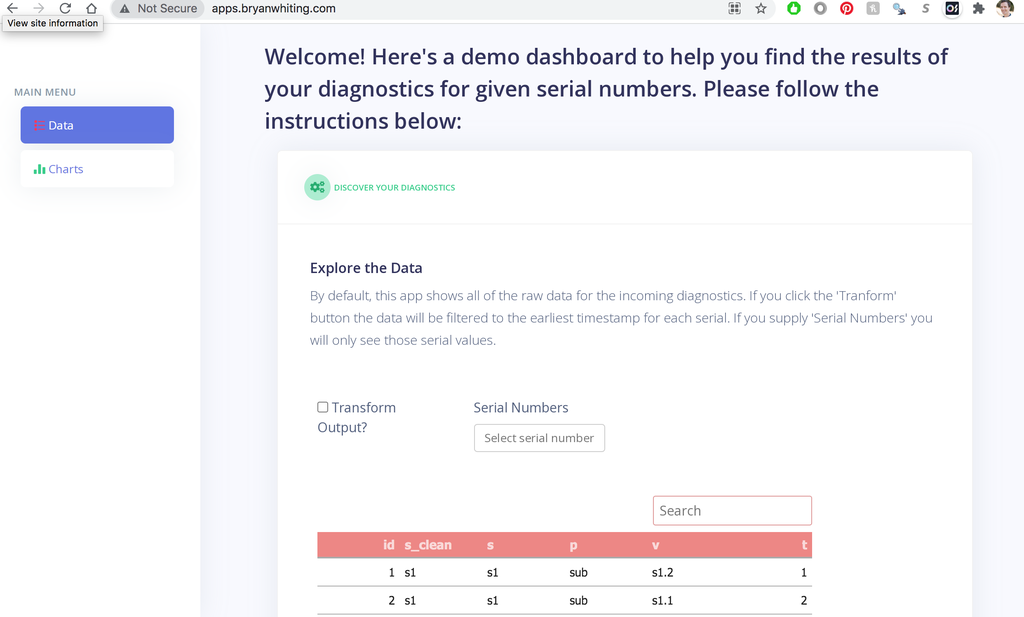

The dash lets you transform your data:

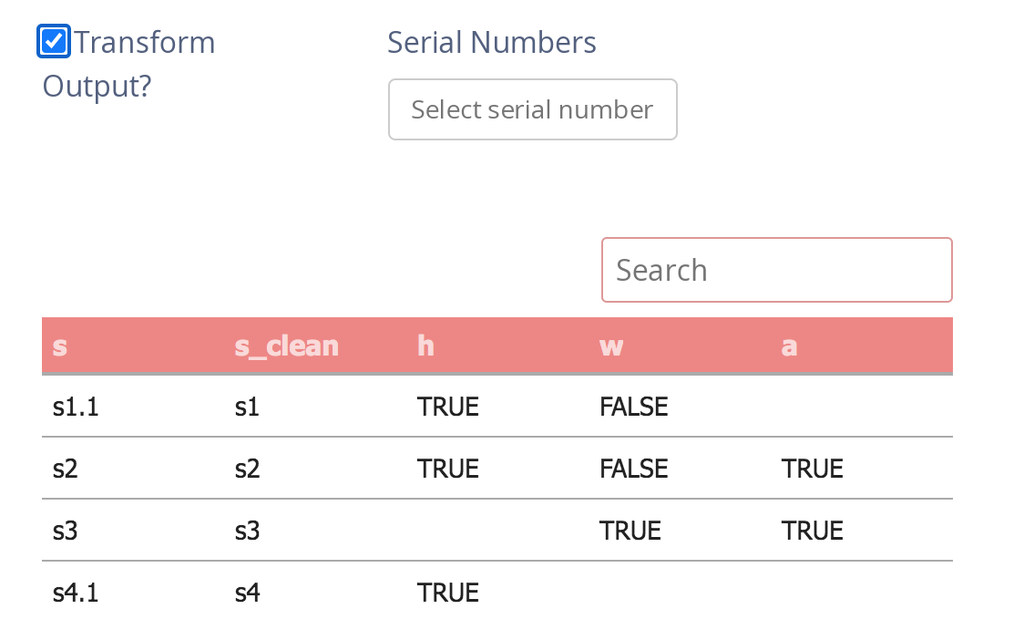

And it also lets you use `selectize` multiple selection to filter to seria numbers you care about:

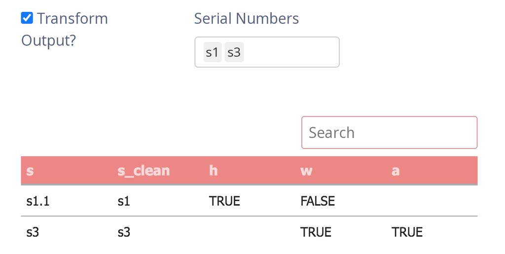

### Charts

On the `Charts` tab, users can see trends in the data. They can interact with those charts to identify anomalies.

## App Tech Stack

Code for the app, [Dockerfile]](https://github.com/bryanwhiting/sqlite_test/tree/main/Dockerfile).

- Built a docker image on my mac for prototyping
- Used [R Shiny](https://shiny.rstudio.com/) as my interactive web app
- Used [argonDash](https://rinterface.github.io/argonDash/) theming on top of `shiny` to get a beautiful UI out of the box.
- Pushed docker image to dockerhub bryanwhiting/argonapp
- Launched EC2 instance with appropriate ports exposed (80, 443, and 8080 for the API)
- SSH’d into the EC2, installed command-line tools, and pulled my docker container
- Cloned this repo: https://github.com/bryanwhiting/sqlite_test, which had my app
- Ran my docker container, mounting my app, and exposing the ports so they can be viewed globally
- Created a personal DNS on my private website: `apps.bryanwhiting.com`
- Used Route53 to forward my EC2’s ip address to my personal DNS.

## API

Code for the [API](https://github.com/bryanwhiting/sqlite_test/tree/main/api), [Dockerfile]](https://github.com/bryanwhiting/sqlite_test/tree/main/api/Dockerfile).

Prior to this experience, I had never built an API. I researched how to build an API in R, and came across the [`plumber`](https://www.rplumber.io/) package. I ventured to replicate the App’s functionality, but as an API.

### Curling my API on the Terminal

The API is accessible via `apps.bryanwhiting.com:8080/inspect`. Calling just `/inspect` will return the full dataset in json. If you want to filter to a specific serial number, call `/inspect?serials=s1`, or `/inspect?serials=s2`. To call multiple, use a pipe: e.g., `s1|s4` (the pipe is `%7C`), or `/inspect?serials=s1%7Cs2`.

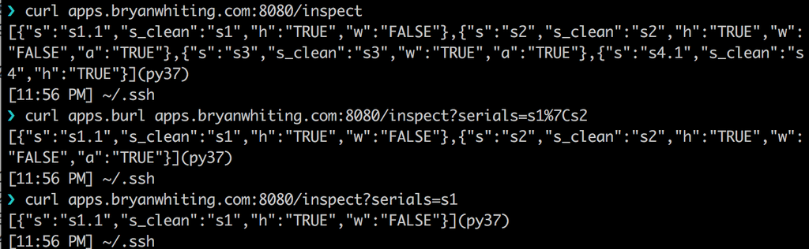

If you enter a bad serial number, you’ll get a helpful error:

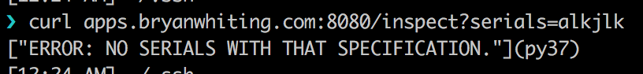

### Getting my API on the Browser

Accessing the API via the web, you get this:

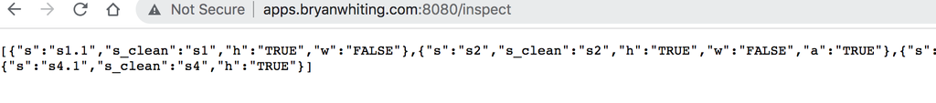

### `/plot` endpoint from the API

The API can also generate plots: apps.bryanwhiting.com:8080/plot

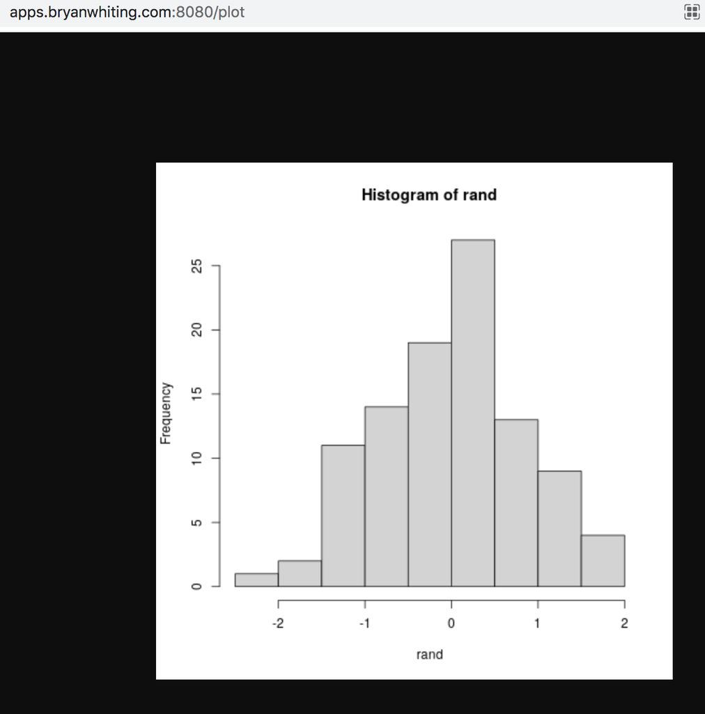

This plot just generates random data every time you call it, but it could easily generate valuable insights about the serial numbers.

## API Tech Stack

- [`plumber`](https://www.rplumber.io/) as the API, inspired by Python’s `flask`
- Created docker container bryanwhiting/plumber
- Launched container on same AWS instance, exposing to port 8080.

# Future Ideas with More Time

With more time, I would do the following:

App:

- To the app, add ML-driven, time-series anomaly detection
- Add user-login to the app
- Have automated, user-specific notifications in the user’s profile
- Add auto-emailing using [`blastula`](https://github.com/rstudio/blastula) when anomalies arise
- Scale the app on ECS so it can be more reliable

Code:

- Package the data-processing code and add unit tests
- Add CI/CD checks (security, linting, etc.) using GitHub Actions